# Introduction to ggplot for Visualization

The outline, explanations, and code examples for this workshop are derived from the work found in the [*Data Visualization* chapter](http://r4ds.had.co.nz/data-visualisation.html) and the [*Graphics for Communication* chapter](http://r4ds.had.co.nz/graphics-for-communication.html) of Hadley Wickham’s [*R for Data Science*](http://r4ds.had.co.nz/). If you are borrowing or referring to this introduction, please reference the Wickham as the source material. My goal with this document is to create and outline for a two hour workshop on `ggplot`. The intellectual work is clearly that of Wickham. Solutions to Wickham’s questions can be found in Jeffrey Arnold’s [R for Data Science Solutions](https://jrnold.github.io/r4ds-exercise-solutions/).

## Prerequisites

You’ll need

- R
- RStudio
- [Tidyverse](https://tidyverse.org/)

This tutorial assumes you already have R and RStudio installed. Once you have launched RStudio, load the tidyverse super package of libraries: `library(tidyverse)`. Since the Tidyverse packages include the ggplot2 package you do not have to load ggplot2 separately. If the `library(tidyverse)` command gives an error, you probably want to `install.packages("tidyverse")` before attaching the library. Installation need only be done once. Attaching the tidyverse library must be done each time your script.

```r
library(tidyverse)
library(sf)
```

## Basic syntax

`ggplot` syntax template is as follows…

```r
ggplot(data = <DATA>) +
  <GEOM_FUNCTION>(mapping = aes(<MAPPINGS>))
```

- The **data** argument takes a **Tibble** (or data frame)
- The **pipe operator** for `ggplot` is a plus sign **`+`**.
  - This is different from the rest of the tidyverse, which came later and settled on the [magritter](https://magrittr.tidyverse.org/) style of pipe operator: `%>%`
  - Tidyverse currently uses two different pipe operators, depending on the package. The two styles of pipe operator are dependent on particular packages within the Tidyverse and are not interchangable.
- The **GEOM_FUNCTION** is a function of your choosing, used to plot your visualization.
  - Some of the most common *geoms* are scatter plots, bar plots, and box plots.
  - There are numerous geom_functions. At some point you will want to [browse the well crafted documentation](https://ggplot2.tidyverse.org/reference/index.html) and learn about other GEOMs.
- The **mapping** function requires, minimally, the [**`aes()`**](https://ggplot2.tidyverse.org/reference/aes.html) function.
  - This enables you to assign assign the variables of your data frame to the appropriate axis in your plot.

Below is a basic example. The `geom_point()` function generates a scatter plot from the on-board **mpg** tibble, a dataset of fuel economy data compiled by the US government. `displ` and `hwy` are variables in the dataset assigned to the x and y axis, respectively.

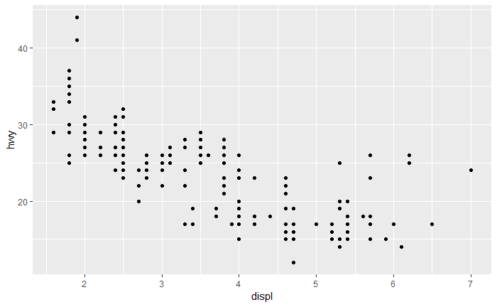

```r
ggplot(data = mpg) +
  geom_point(mapping = aes(x = displ, y = hwy))
```

### The Data

As stated above, ggplot takes a tibble (data frame) for input. Beyond identifying the data source, one has to map the variables to a geom (~ axis). Different *geoms* require different data types. Understanding the definitions of continuous, categorical, and discrete variables – as well understanding **R** data structures (factors, vectors, data/time, strings) – will be immensely helpful to you. You can read all about that in Wickham’s *R4DS* book. Meanwhile, let’s have a look at the `mpg` data we just visualized. Look up the on-board dataset in the help: `?mpg` to learn more about the variables.

```r
mpg
```

| manufacturer | model | displ | year | cyl | trans | drv | cty | hwy | fl | class |
| --- | --- | --- | --- | --- | --- | --- | --- | --- | --- | --- |
| audi | a4 | 1.8 | 1999 | 4 | auto(l5) | f | 18 | 29 | p | compact |
| audi | a4 | 1.8 | 1999 | 4 | manual(m5) | f | 21 | 29 | p | compact |
| audi | a4 | 2.0 | 2008 | 4 | manual(m6) | f | 20 | 31 | p | compact |
| audi | a4 | 2.0 | 2008 | 4 | auto(av) | f | 21 | 30 | p | compact |
| audi | a4 | 2.8 | 1999 | 6 | auto(l5) | f | 16 | 26 | p | compact |
| audi | a4 | 2.8 | 1999 | 6 | manual(m5) | f | 18 | 26 | p | compact |
| audi | a4 | 3.1 | 2008 | 6 | auto(av) | f | 18 | 27 | p | compact |
| audi | a4 quattro | 1.8 | 1999 | 4 | manual(m5) | 4 | 18 | 26 | p | compact |
| audi | a4 quattro | 1.8 | 1999 | 4 | auto(l5) | 4 | 16 | 25 | p | compact |
| audi | a4 quattro | 2.0 | 2008 | 4 | manual(m6) | 4 | 20 | 28 | p | compact |

[output cut: 224 more lines]

### Exercies

1. Make a scatter plot of `hwy` vs `cyl`. (Question from [R4DS](http://r4ds.had.co.nz/data-visualisation.html#exercises) | [Solution](https://jrnold.github.io/r4ds-exercise-solutions/data-visualisation.html#exercise-3.2.4.))

## Aesthetics / Tweaking

In his book, *R4DS*, Wickham notes there are some `mpg` data points that seem to fall outside the linear trend. Specifically, se the blue data points below. To investigate trends such as this, use `ggplot` to alter the levels of the aesthetics. We’ll discuss how to map the aesthetic levels throughout this workshop. Remember, this material is presented in *R4DS*.

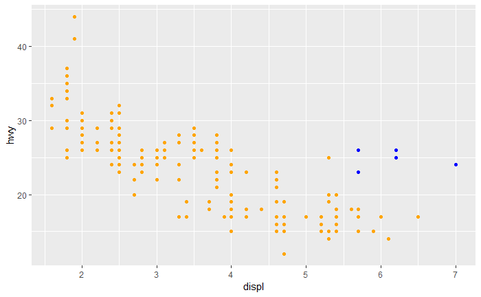

### Levels

- An **aethetic** is a visual property of objects in the plot. For example: **shape**, **color**.
  - See Also: *size*, opacity (*alpha*), *stroke*, and more
- Each property can have different **levels**. For example some levels of shape are *circle*, *square*, *triangle*. By adding variables and/or changing the levels of the aesthetics you can change the visual appearance. The effectiveness of the different aesthetics will vary with the data type. R will often provide warnings – suppressed in this tutorial – depending on the quality of the mapping association.

#### Color

Below, map a third variable, `class` to the color aesthetic.

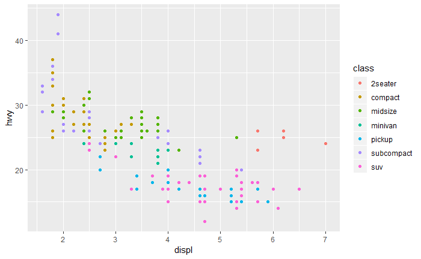

```r
ggplot(data = mpg) +
  geom_point(mapping = aes(x = displ, y = hwy, color = class))
```

#### Shape

We can change the shape aesthetic in the same way as we changed the color. Notice, R will only map to six distinct shapes. (Learn more by `?pch`, or Google Search for “shapes in R”)

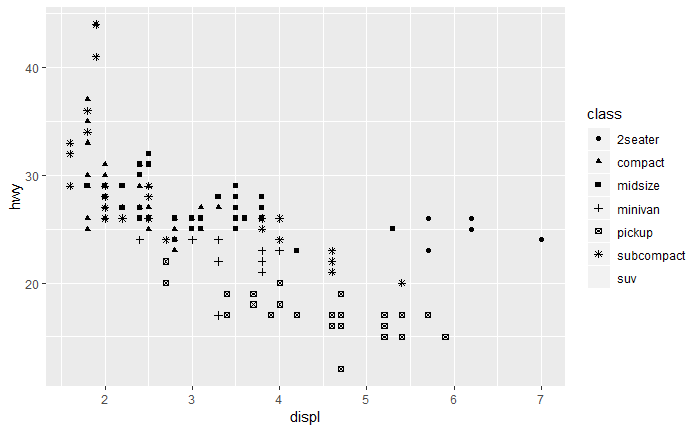

```r
ggplot(data = mpg) +
  geom_point(mapping = aes(x = displ, y = hwy, shape = class))
```

### Manual vs automatic aethetics

- Levels mapped inside the `aes()` are assigned dynamically.
- Levels mapped **manually** outside the `aes()`, but still inside the `geom_()`, are static. This allows the coder to some flexibility. For Example: See below `color = "blue"` is outside the aesthetic but inside the geom function.

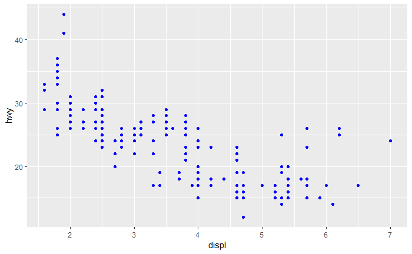

```r
ggplot(data = mpg) +
  geom_point(mapping = aes(x = displ, y = hwy), color = "blue")
```

### Exercises

#### 3.3.1.1

([Question](http://r4ds.had.co.nz/data-visualisation.html#exercises-1)) What’s gone wrong with this code? Why are the points not blue? ([Solution](https://jrnold.github.io/r4ds-exercise-solutions/data-visualisation.html#exercise-3.3.1))

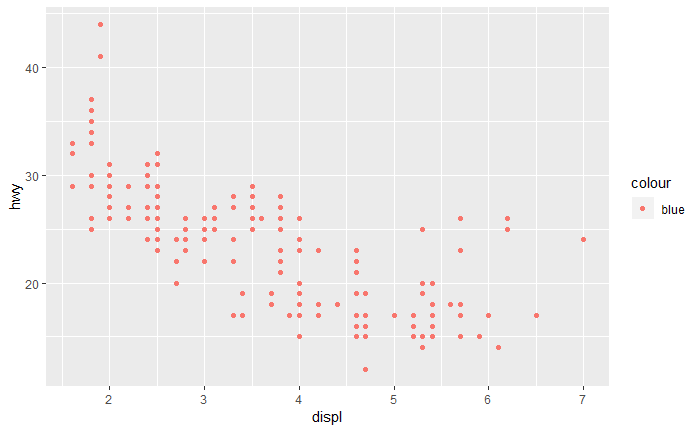

```r
ggplot(data = mpg) +
  geom_point(mapping = aes(x = displ, y = hwy, color = "blue"))
```

#### 3.3.1.3

Map a continuous variable to color, size, and shape. How do these aesthetics behave differently for categorical vs. continuous variables? [Solution](https://jrnold.github.io/r4ds-exercise-solutions/data-visualisation.html#exercise-3.3.3)

#### 3.3.1.4

What happens if you map the same variable to multiple aesthetics? [Soluion](https://jrnold.github.io/r4ds-exercise-solutions/data-visualisation.html#exercise-3.3.4)

### Aethetics revisited

#### Stroke

Above I noted that there are many different aesthetics including **shape**, **color**, *size*, opacity (*alpha*), and *stroke*. Let’s take a look at `stroke` and note two additional features…

- When using `stroke`, also use `fill`
- `stroke` may not work with every [shape](http://r4ds.had.co.nz/data-visualisation.html#fig:shapes). Check the help pages for more information

Below the `stroke` (line thickness) is set to 3. The color of the stroke is cadetblue4.

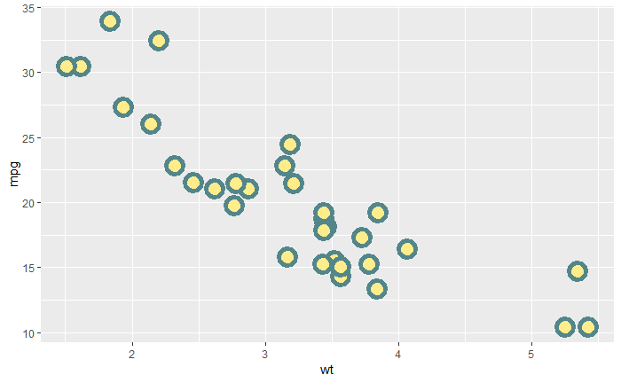

```r
ggplot(mtcars, aes(wt, mpg)) +
  geom_point(shape = 21, color = "cadetblue4", fill = "lightgoldenrod1", size = 5, stroke = 3)
```

## Layers

### Regression Line

Like many graphics programs you can built your vector graphics in layers. For example, add a regression line with `geom_smooth()`

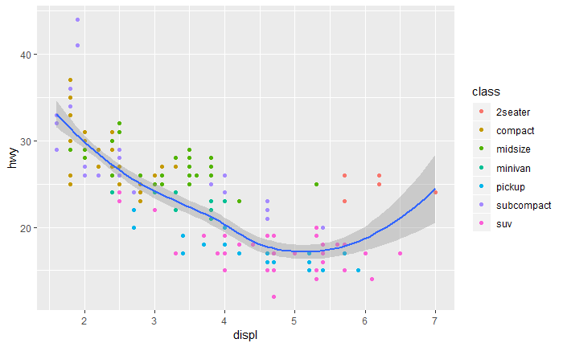

```r
ggplot(data = mpg) +
  geom_point(mapping = aes(x = displ, y = hwy, color = class)) +
  geom_smooth(mapping = aes(x = displ, y = hwy))
```

### ggplot R object

To clarify code changes, let’s introduce some code changes. All ggplot plots can be assigned as an R object. So, for example…

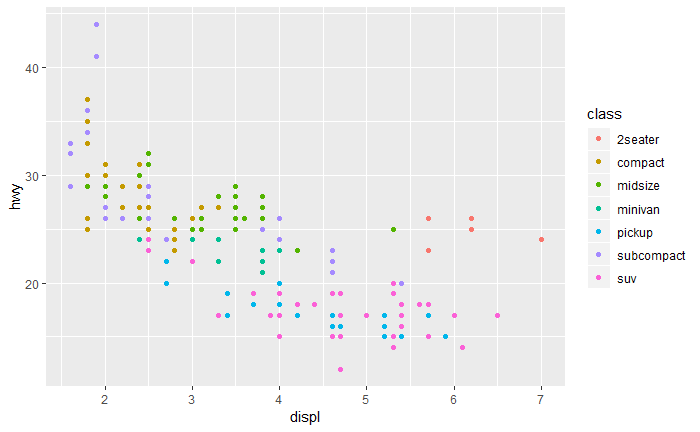

```r
hwy_plot <- ggplot(data = mpg) +
  geom_point(mapping = aes(x = displ, y = hwy, color = class))
hwy_plot
```

Now it will be easier to see the code changes. Building the same layered plot as before, this time you can more easily see the code change: `geom_smooth(mapping = aes(x = displ, y = hwy))`

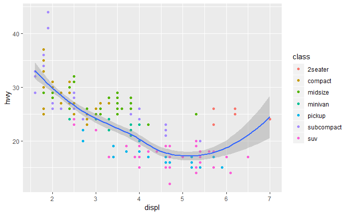

```r
hwy_plot +
  geom_smooth(mapping = aes(x = displ, y = hwy))
```

### Additional Aesthetics

In the next example, notice the regression_line aesthetic operates the same as before but is applied to a categorical variable. A third variable, `drv`, is used to highlight a new level in the aesthetic. In this case, we’ll show different levels of regression based on the categorical `drv` variable.

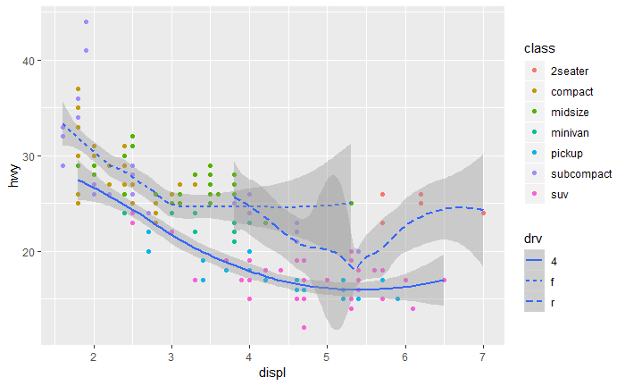

```r
hwy_plot +
  geom_smooth(mapping = aes(x = displ, y = hwy, linetype = drv))
```

### Standard Error

Since each geom can have it’s own unique arguments, consult the documentation to learn how to manipulate the appearance. Here we can consult `?geom_smooth` and learn how to remove the standard error shading by setting `se = FALSE`.

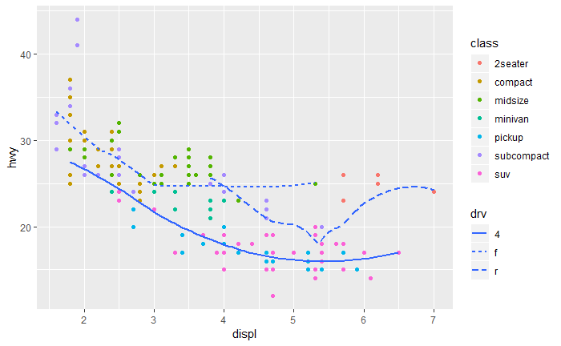

```r
hwy_plot +
  geom_smooth(mapping = aes(x = displ, y = hwy, linetype = drv), se = FALSE)
```

### Exercises

http://r4ds.had.co.nz/data-visualisation.html#exercises-3

#### 3.6.1.5

Will these two graphs look different? Why/why not? [Solution](http://r4ds.had.co.nz/data-visualisation.html#exercises-3)

```r
ggplot(data = mpg, mapping = aes(x = displ, y = hwy)) +
  geom_point() +
  geom_smooth()

ggplot() +
  geom_point(data = mpg, mapping = aes(x = displ, y = hwy)) +
  geom_smooth(data = mpg, mapping = aes(x = displ, y = hwy))
```

#### 3.6.1.6

Recreate the R code necessary to generate the graphs found at [3.6.1.6](http://r4ds.had.co.nz/data-visualisation.html#exercises-3) | [Solutions](https://jrnold.github.io/r4ds-exercise-solutions/data-visualisation.html#exercise-3.6.6)

## Facets

### facet_wrap

Facet a plot on a single discrete variable, e.g. the `class` variable that categorically identifies the type of automobile (e.g. compact, midsize, minivan, etc.)

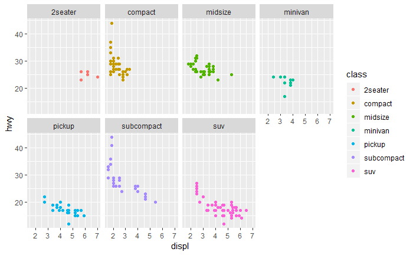

```r
hwy_plot +
  facet_wrap(~ class, nrow = 2)
```

### facet_grid

facet a plot on two variables

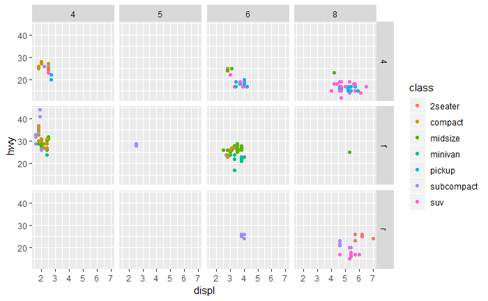

```r
hwy_plot +
  facet_grid(drv ~ cyl)
```

## Statistical Transformations

Importantly, you need to know which geom arguments to use for your desired outcome. Below the `geom_bar` and `stat_count` demonstrate the issue. `geom_bar` & `stat_count` can generally be used interchangeably.

### Bar Plot

In the next sets of examples we will use the on-board dataset, *diamonds*. Diamonds is a dataset covering various characteristics of the precious gem. You can get help on *diamonds*: `?diamonds`

#### Automtic Categorization

By default the `geom_bar` and `stat_count` will total the raw numbers from the data frame.

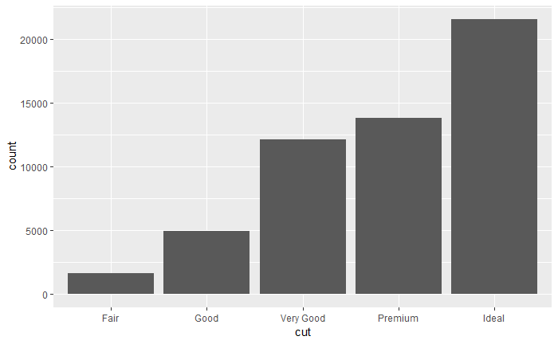

```r
ggplot(data = diamonds) +
  geom_bar(mapping = aes(x = cut))
```

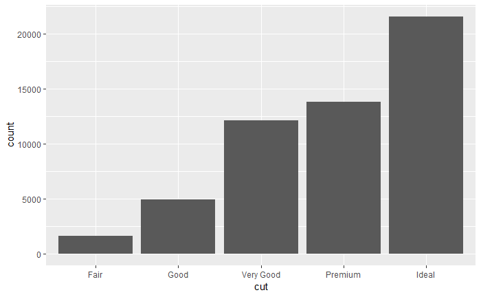

```r
ggplot(data = diamonds) +
  stat_count(mapping = aes(x = cut))
```

#### Overriding the default

As shown above performing statistical transformations by calculating summary totals for variables, above, is a convenient default setting in ggplot::geom_bar and for other particular geoms. Sometimes I find it more logical to use `dplyr` (and `forcats`) to generate summary tables. However, the totals then have to be handled in a special manner after piping to ggplot (`stat = "identity`).

##### identity

use the pre-define totals “as is”: (`stat = "identity`)

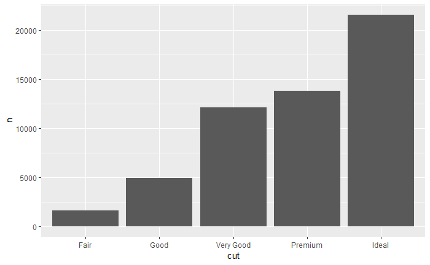

```r
diamonds %>%
  count(cut) %>%
  ggplot() +
  geom_bar(mapping = aes(x = cut, y = n), stat = "identity")
```

```r
NA
```

##### Proportion

generating a proportion automaticaly is super nifty…

`y = ..prop.., group = 1`

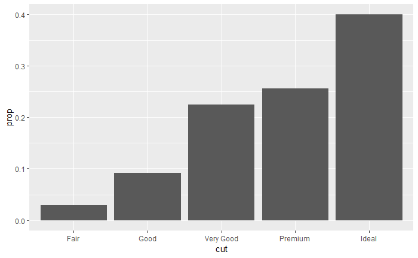

```r
ggplot(data = diamonds) +
  geom_bar(mapping = aes(x = cut, y = ..prop.., group = 1))
```

#### Fill color

`fill = cut`

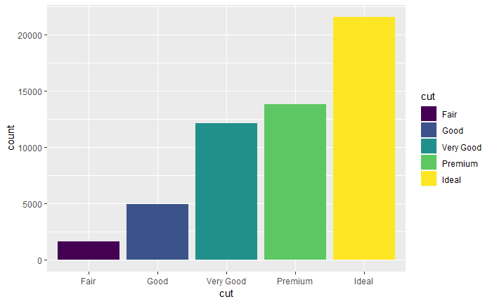

```r
ggplot(data = diamonds) +
  geom_bar(mapping = aes(x = cut, fill = cut))
```

#### Stacked

`fill = clarity`

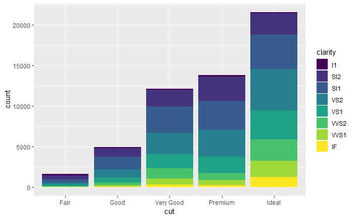

```r
ggplot(data = diamonds) +
  geom_bar(mapping = aes(x = cut, fill = clarity))
```

#### Side by Side

`position = "dodge"`

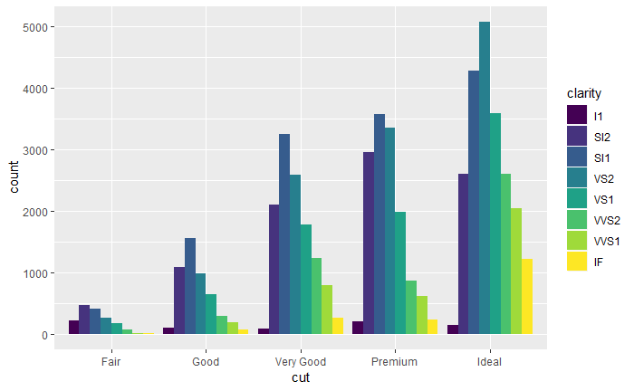

```r
ggplot(data = diamonds) +
  geom_bar(mapping = aes(x = cut, fill = clarity), position = "dodge")
```

## Jitter

`jitter` can help solve the problem of **overplotting**, as can `dodge` discussed above.

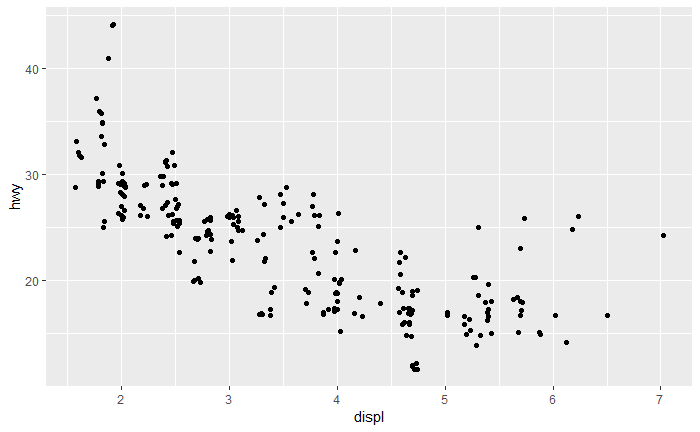

```r
ggplot(data = mpg) +
  geom_point(mapping = aes(x = displ, y = hwy), position = "jitter")
```

## Other geom_s ?

There are a lot of options and visualizations available to you via ggplot. The challenge becomes knowning what you can create based on the characteristics of your data. The ggplot2 cheat sheet – available from the **H**elp menu inside RStudio – can help you choose the appropriate geom for your data. Examples on the cheat sheet will lead you to choose geoms based on characteristics such as, one continuous variable, two continuous, one discrete + one continuous, discrete by discrete, three variables, etc. Look closely at this useful reference.

## Coordinate System

### Flip

`coord_flip()`

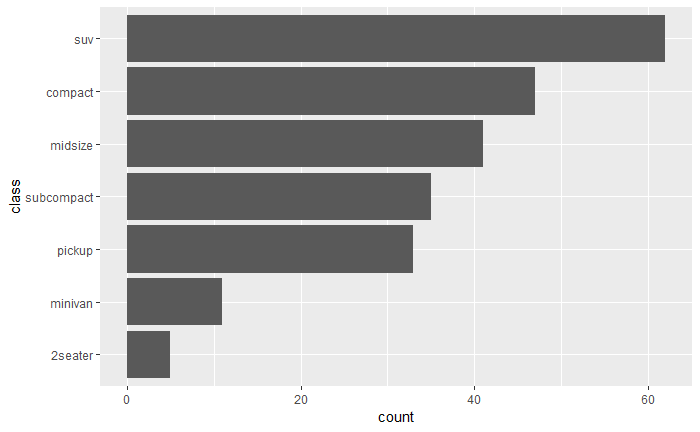

```r
mpg %>%
  mutate(class = class %>% fct_infreq() %>% fct_rev()) %>%
  ggplot(aes(class)) +
  geom_bar() + coord_flip()
```

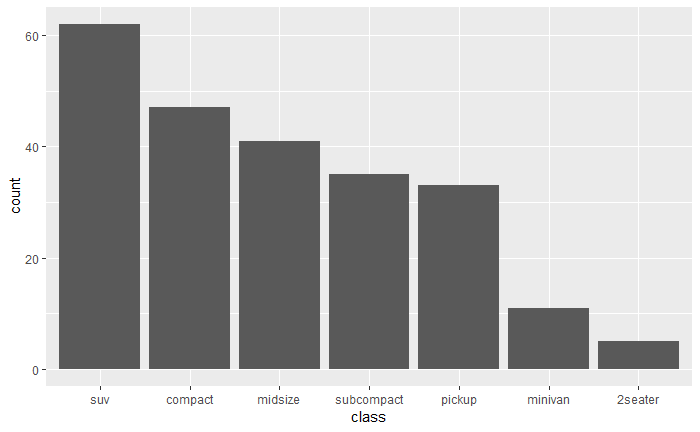

```r
mpg %>%
  mutate(class = class %>% fct_infreq()) %>%
  ggplot(aes(class)) +
  geom_bar()
```

### Mapping / GIS

Mapping and GIS is supported quite well using `ggplot` combined with the `sf` GIS package. Interactive maps can also be generated by investigating the `mapbox` and `leaflet` packages. Thematic maps can be generated with the `tm` package. Census choropleths can be supported using the `tidycensus` and `tigris` packages. If you’re new to GIS I encourage you to learn more from the [Mapping in R](https://rfun.library.duke.edu/map/) resource page. Below is an example map generated by transforming some on-board GIS data for North Carolina and found in the `demo()` package. Some of the ggplot customizations demonstrate techniques you’ll learn in the following sections of this workbook.

```r
demo(nc, ask = FALSE, echo = FALSE)  # Generate a sample map of North Carolina using on-board demo data
```

```
Attribute-geometry relationship: 0 constant, 8 aggregate, 6 identity
geometry type:  MULTIPOLYGON
dimension:      XY
bbox:           xmin: -84.32385 ymin: 33.88199 xmax: -75.45698 ymax: 36.58965
epsg (SRID):    4267
proj4string:    +proj=longlat +datum=NAD27 +no_defs
```

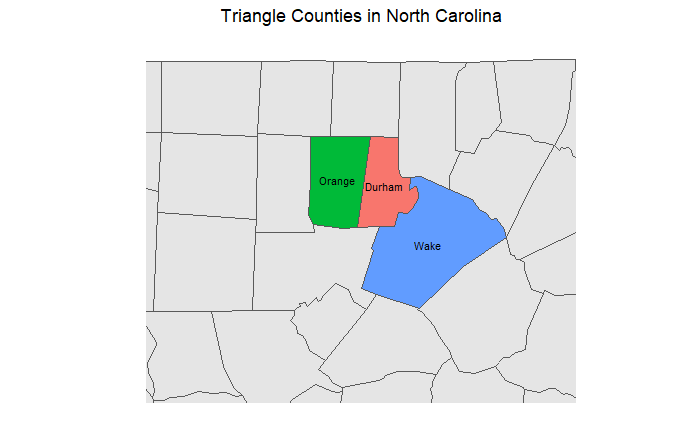

```r
triangle <- nc %>%
  filter(NAME == "Durham" |
           NAME == "Orange" |
           NAME == "Wake")
tri_roid <- st_centroid(triangle)
triangle <- cbind(triangle, st_coordinates(tri_roid))
ggplot() +
  geom_sf(data = nc) +
  geom_sf(data = triangle, aes(fill = NAME)) +
  coord_sf(xlim = c(-78, -80), ylim = c(35.2,36.6)) +
  geom_text(data = triangle, aes(label = NAME, x = X, y = Y), size = 3) +
  theme(legend.position = "none",
        panel.background = element_rect(fill = "transparent"),
        panel.grid.major = element_line(color = "transparent"),
        axis.text.x = element_blank(),
        axis.text.y = element_blank(),
        axis.ticks = element_blank(),
        plot.title = element_text(hjust = 0.5)) +
  ylab("") +
  xlab("") +
  ggtitle("Triangle Counties in North Carolina")
```

## Color Scales

`ggplot` offers several default scales. Scales can be used to tweak more than color. The *Scales* section of the *Graphics for Communication* chapter ([R4DS](http://r4ds.had.co.nz/graphics-for-communication.html)) should be read for understanding. You can tweak the aesthetics for continuous, discrete, datetime, or date variables. Scales are also used to change axis breaks, labels and legends.)

**Color scales** are often used to change color for **improved visual clarity.** Two of the most common packages for this are the `RColorBrewer` and `viridis` packages. Below the “Dark2” palette option from the RColorBrewer set is associated with the categorical `mpg$class` variable. Aside from “Dark2”, find the names of other ColorBrewer palette names in many places: `?scale_colour_brewer`, Google, R4DS, etc.

`scale_color_brewer(palette = "Dark2")`

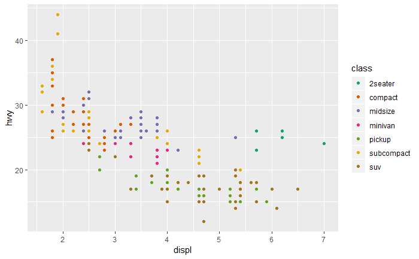

```r
hwy_plot +
  scale_color_brewer(palette = "Dark2")
```

Viridis may work better for continuous variables, rather than discrete. However, below is an example of the viridis package changing the color scale.

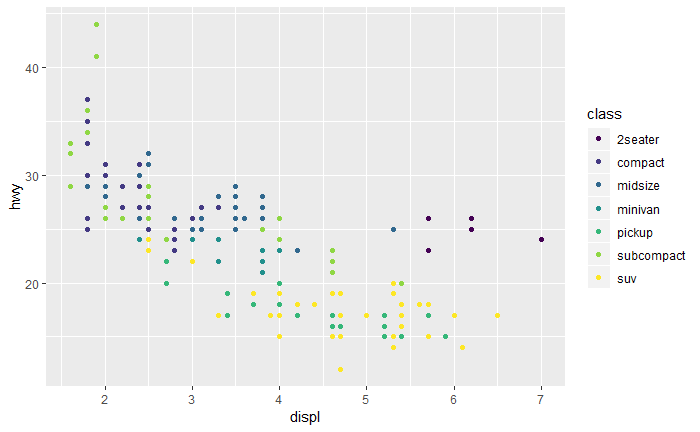

```r
hwy_plot +
  viridis::scale_color_viridis(discrete=TRUE)
```

Below is another example this time using a continuous variable, `diamonds$price` to demonstrate color. The first plot uses the ggplot default.

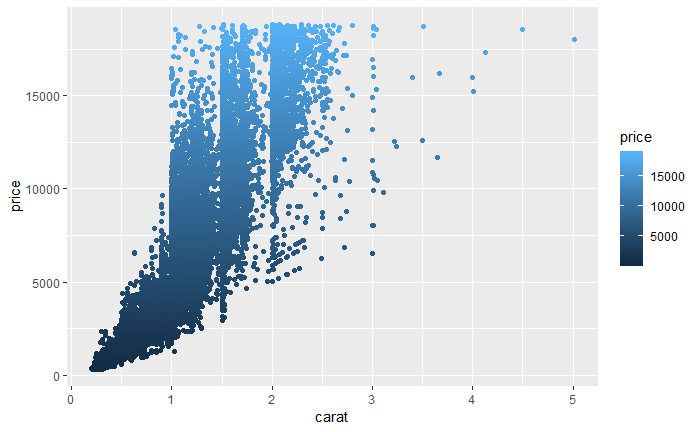

```r
ggplot(data = diamonds) +
  geom_point(mapping = aes(x = carat, y = price, color = price))
```

The second plot uses the viridis package to override the default color scale. (Aditionally, the alpha aesthetic is mapped to better accomodate overplotting.)

`viridis::scale_color_viridis()`

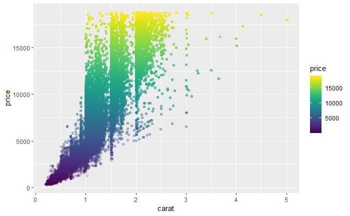

```r
ggplot(data = diamonds) +
  geom_point(mapping = aes(x = carat, y = price, color = price, alpha = price / 10000)) +
  viridis::scale_color_viridis() +
  guides(alpha = FALSE)
```